# Homelessness in America

Jake Lehrhoff

October 4, 2015

### Background

Our world is filled with that which we choose to not see, from the rat population in New York to iTunes user agreements, all for the benefit of streamlining our own existence. A far less insubstantial marginalized aspect of society is the **homeless**, a population comprised of the young and old, parents and children, veterans, the mentally ill, and the unlucky.

Startlingly, estimates of mental illness in the homeless population are [as high as 33%](http://www.treatmentadvocacycenter.org), the vast majority of which are untreated.

### Research Goals

- Investigate state homeless populations
- Analyze the link between temperature and homeless populations
- Probe the relationship between mental health spending and homeless populations

### Data

- 2009 Annual Homeless Assessment Report (AHAR) to Congress
- 2013 Annual Homeless Assessment Report (AHAR) to Congress
- National Alliance on Mental Health – State Mental Health Cuts: The Continuing Crisis
- Average winter temperature by state

### Setup and Cleaning Homeless and Mental Health Data

This data came from pdf files (AHAR and NAMH) and tables embedded in websites (weather data). Therefore, cleaning was a major component of this project. Tabula, a program for extracting data from pdf files, was an effective method for retrieving the homeless and mental health data; however, the resulting csv files required extensive cleaning. Extra spaces, commas, and percentage symbols had to be removed before tables could be manipulated or joined. For simplicity, a new table was created with just the variables of interest.

```r
knitr::opts_chunk$set(warning=FALSE, message=FALSE)
setwd("/Users/jacoblehrhoff/desktop/nycdsa/bootcamp003_student/Project1-ExploreVis/Jake/data/")

library(dplyr)
library(ggplot2)
library(ggthemes)
library(RColorBrewer)
library(grid)
library(XML)

# function for cleaning symbols out of numbers in data
as.numeric.func <- function(x, y) {
  as.numeric(gsub(y,"", x))
}

homeless2009 <- read.csv("2009_homeless_estimates.csv", header = TRUE, stringsAsFactors = FALSE)

# Remove %
homeless2009$Homeless.Rate <- as.numeric.func(homeless2009$Homeless.Rate, "%")

# Remove commas, change names, create unsheltered rate, select relevant columns
homeless2009a <- data.frame(homeless2009, lapply(homeless2009[2:5], as.numeric.func, y = ",")) %>%
  mutate(., Homeless2009 = Homeless.Population.1, Sheltered2009 = Sheltered.Population,
         Unsheltered2009 = Unsheltered.Population.1, StatePop2009 = State.Population.1,
         HomelessRate2009 = Homeless.Rate, UnshelteredRate2009 = (Unsheltered2009 / Homeless2009) * 100,
         State = as.character(State)) %>%
  select(., State, Homeless2009, HomelessRate2009, UnshelteredRate2009, StatePop2009)

# Remove spaces after state names
homeless2009a$State <- substr(homeless2009a$State, 1, nchar(homeless2009a$State) - 1)

homeless2013 <- read.csv("2013_Homeless.csv", header = TRUE, stringsAsFactors = FALSE)

# remove commas and %
homeless2013$Homeless2013 <- as.numeric.func(homeless2013$Total.Homeless.Persons, ",")
homeless2013$Unsheltered.persons....Homeless.population. <-
  as.numeric.func(homeless2013$Unsheltered.persons....Homeless.population., "%")

# Rename and select columns
homeless2013a <- mutate(homeless2013, HomelessRate2013 = (Homeless2013/Population)*100,
                        UnshelteredRate2013 = Unsheltered.persons....Homeless.population.,
                        State = as.character(State), StatePop2013 = Population) %>%
  select(., State, Homeless2013, HomelessRate2013, UnshelteredRate2013, StatePop2013)

# join homeless data
data <- inner_join(homeless2009a, homeless2013a, by = "State")

state_MH_budget <- read.csv("State_Mental_Health_Budget.csv", header = TRUE,
                            stringsAsFactors = FALSE, fileEncoding = "latin1")

# Change column names
state_MH_budget <- mutate(state_MH_budget, Budget2009 = FY2009..Millions., Budget2012 = FY2012..Millions.,
                          BudgetPercentChange = Percent.Change) %>%
  select(., State, Budget2009, Budget2012, BudgetPercentChange)

state_MH_budget$BudgetPercentChange <- as.numeric.func(state_MH_budget$BudgetPercentChange, "%")

# Manipulating budget data and joining
data <- inner_join(data, state_MH_budget, by = "State")
data <- mutate(data, BudgetRank = as.integer(rank(desc(BudgetPercentChange))),
               HomelessChangeRank = as.integer(rank(HomelessRate2013-HomelessRate2009)),
               RankDiff = as.integer(rank(HomelessChangeRank - BudgetRank)),
               extreme = ifelse(RankDiff > 47, 1, ifelse(RankDiff < 4, -1, 0)))
```

### Weather and Map Data

```r
urlWin <- "http://www.currentresults.com/Weather/US/average-state-temperatures-in-winter.php"
winterTemp <- readHTMLTable(urlWin, header = TRUE, stringsAsFactors = FALSE)

# Change names
winterTemp$`Average temperature for each state during winter.`$AvgW <-
  as.numeric(winterTemp$`Average temperature for each state during winter.`$`Avg Â° F`)
winterTemp$`NULL`$AvgW <- as.numeric(winterTemp$`NULL`$`Avg Â° F`)

# Separate winter tables
winterTemp1a <- select(winterTemp$`Average temperature for each state during winter.`, State, AvgW)
winterTemp1b <- select(winterTemp$`NULL`, State, AvgW)

# Merge winter tables
winterTemp2 <- merge(x = winterTemp1a, y = winterTemp1b, all = TRUE)

# Merge weather with homeless and budget data
data <- merge(x = data, y = winterTemp2)

# Deciding on logical breaks for temperature factor
labels <- c("cold", "moderate", "warm")
minW <- min(data$AvgW)
maxW <- max(data$AvgW)
RangeW <- (maxW-minW)
breaksW <- c(minW, minW + RangeW/3, minW + 2 * RangeW/3, maxW)

# Adding columns with temperature groups
data$Wtemp <- cut(data$AvgW, breaks = breaksW, include.lowest = TRUE)

all_states <- map_data("state")
all_states <- filter(all_states, region!= "district of columbia")
data$region <- tolower(data$State)
Total <- merge(all_states, data, by="region")
```

### Homeless Population by State

To begin the investigation, I looked at the homeless population by state with a choropleth map. California stands out, as it’s homeless population is more than twice that of the next most populous state.

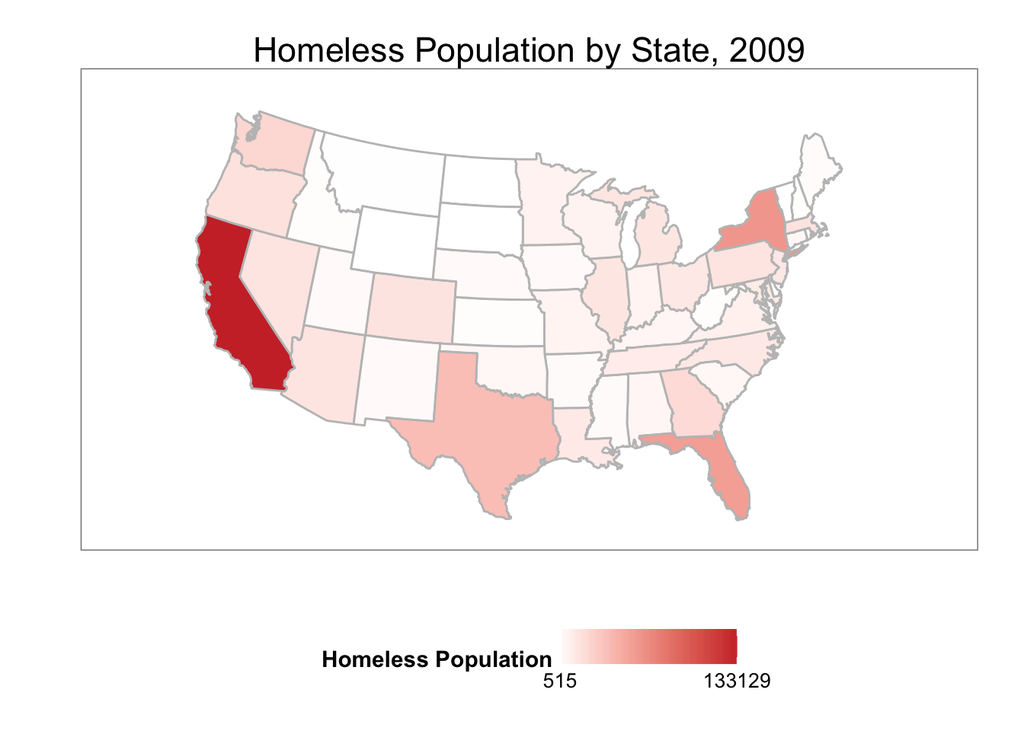

The distribution of homeless populations among “cold,” “moderate,” and “warm” climates is given below. Unsurprisingly, homeless populations are larger in warm climate states, and New York and California stand out with the highest homeless populations.

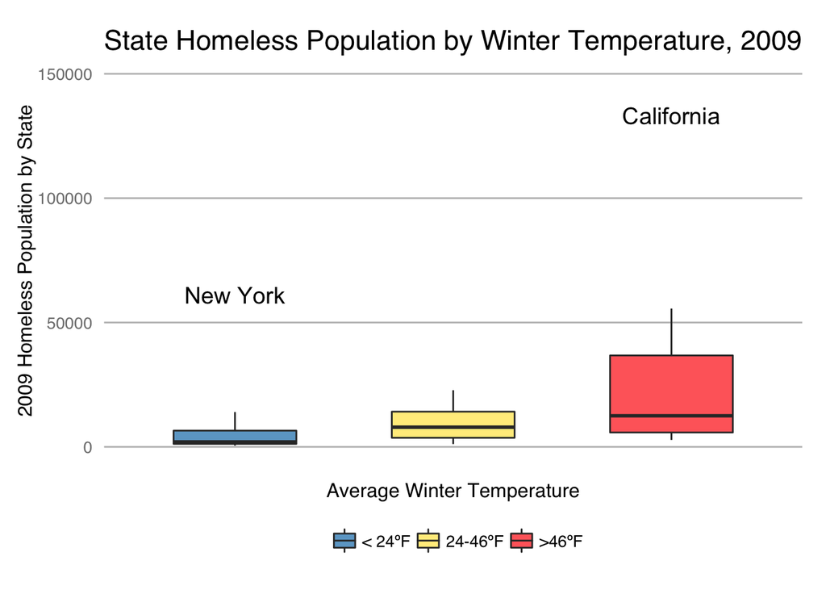

However, more interesting than the homeless population is the homelessness rate. Here, New York is no longer an outlier among cold climate states.

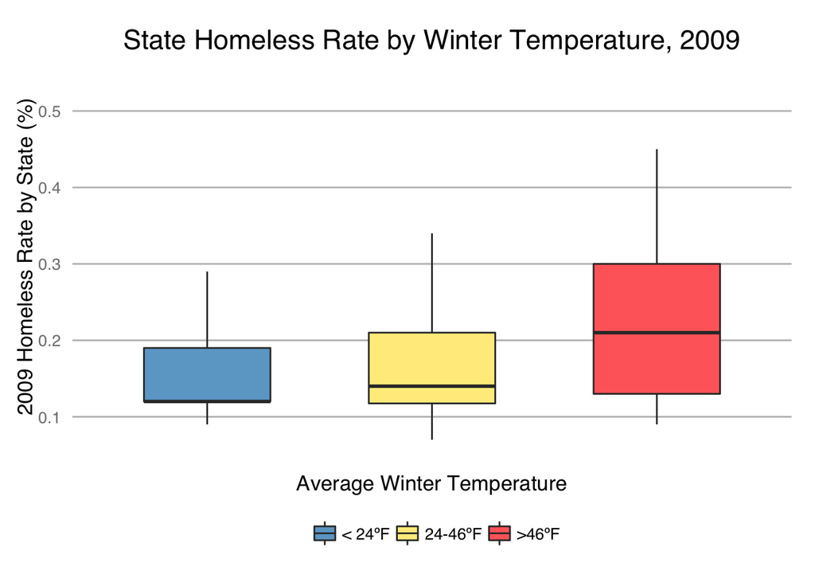

As seen in the density plot, New York stands with Alaska with a slightly higher homelessness rate than other cold climate states, skewing the distribution to the right. Interestingly, the distribution of homelessness among warm weather states is quite broad, with a similar peak as the other climates.

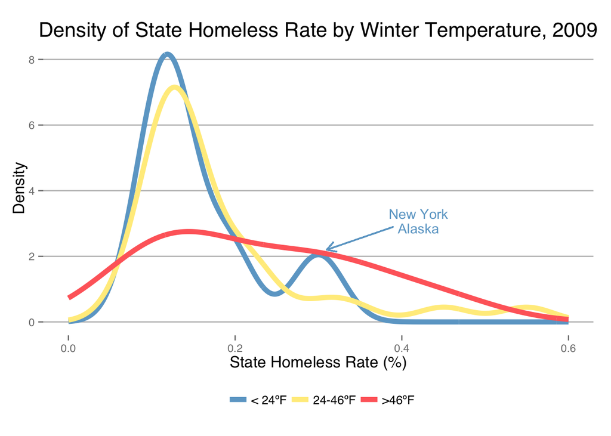

### Changes in Homeless Rates

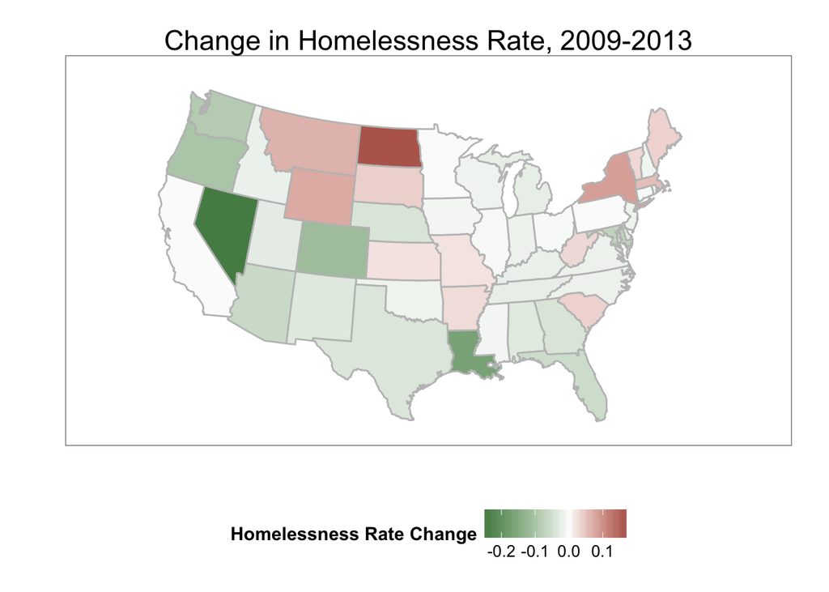

### Unsheltered Homeless

The unsheltered homeless population is the number of people sleeping on the streets on a given night, and is, at best, an estimate. However, some states saw significant shifts in the percentage of the homeless population that went unsheltered, with North Dakota’s unsheltered rate rising a troubling 60 percentage points. This aligns with [reports](http://www.washingtontimes.com/news/2015/feb/23/homelessness-goes-up-as-people-pour-into-north-dak/?page=all) of surging rent in light of bubbling populations, as people flood into North Dakota looking to work in the growing oil industry. Conversely, Louisiana’s unsheltered population dropped by over 20 percentage points, as more years separated the healing city from the devestation of [Hurricane Katrina](http://www.nola.com/politics/index.ssf/2013/03/number_of_homeless_drops_79_pe.html).

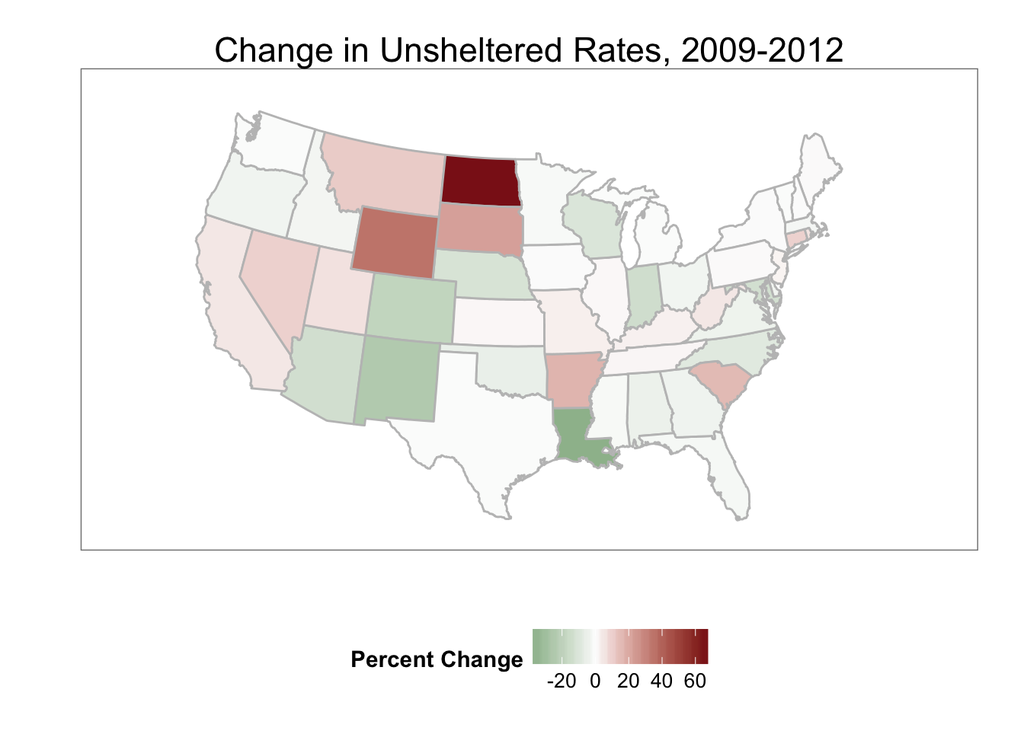

### State Mental Health Budgets

Given the prevalence of mental illness in the homeless population, homeless rates were plotted against mental health spending, with linear regression lines included for reference.

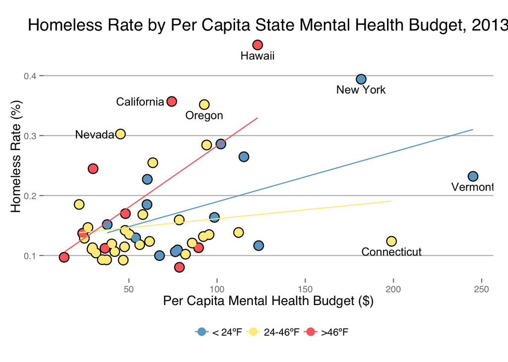

Changes in mental health spending and homeless rates from 2009 to 2013 show modest changes in homeless rates. Despite huge increases in menthal health spending, North Dakota’s homeless rates continue to rise. Nevada, on the other hand, but decreased it’s spending and saw a reduction in homeless rates. However, more current data show that [that trend didn’t last](http://www.helphopehome.org/2014-FINAL-HOMELESS-CENSUS.pdf). Louisiana also saw a decrease in homeless rates with virtually no budgetary change.

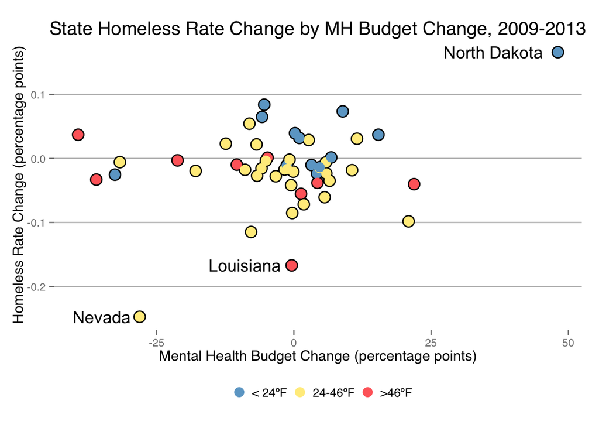

### Conclusions

For more on mental illness and homelessness, these worthy organizations have lots of great information and prominently placed donate buttons, if you feel so inclined.

[National Coalition for the Homeless](http://www.nationalhomeless.org/factsheets/Mental_Illness.html)

[National Alliance to End Homelessness](http://www.endhomelessness.org/pages/mental_physical_health)